# Laboratorio #4 - Método de Monte Carlo para la Optimización de Gestión de Inventarios

## Autores

- Juan Carlos Baján
- José Miguel González
- Luis Pedro Gonzalez

# Task 1

## ¿Cómo afecta la elección de la estrategia de exploración (exploring starts vs soft policy) a la precisión de la evaluación de políticas en los métodos de Monte Carlo?

La estrategia de exploring starts asegura que se exploren una variedad de estados y acciones iniciales, lo que permite una cobertura más completa del espacio de estados y acciones. Esta cobertura completa contribuye a una evaluación más precisa de las políticas, ya que reduce el sesgo hacia ciertos estados o acciones específicos. En particular, exploring starts puede llevar a una estimación más precisa de los valores de estado iniciales, lo cual es crucial en algunos entornos. Sin embargo, esta estrategia puede ser menos eficiente en términos de muestras necesarias, especialmente en espacios de estado grandes.

Por otro lado, soft policy al ser una estrategia epsilon-greedy, balancea la exploración y la explotación al elegir acciones aleatorias con el parámetro epsilon ($\epsilon$) y acciones óptimas con una probabilidad $1-\epsilon$. Si bien esta última continua con la exploración, puede llegar a ser menos exhaustiva, y por tanto menos precisa, que exploring starts, dependiendo de la elección de nuestro parámetro $\epsilon$. Sin embargo, esta estrategia tiene a su favor que puede mejorar su política mientras continua con la exploración. La precisión de soft policy puede variar según el valor de $\epsilon$, sobre todo en cuanto a la convergencia a largo plazo.

Desempeño de las políticas evaluadas con y sin explorar los inicios o con diferentes niveles de exploración en soft-policy:

*Exploración de soft-policy de acuerdo al valor de* $\epsilon$

| Valor de $\epsilon$ | Exploración y desempeño resultante |
| --- | --- |
| $\underset{\epsilon \rightarrow 0}{lim \space \epsilon}$ | Menor exploración, lo que puede resultar en una evaluación más rápida pero potencialmente sesgada hacia las acciones que se consideran actualmente como óptimas. |
| $\underset{\epsilon \rightarrow 1}{lim \space \epsilon}$ | Mayor exploración, lo que puede llevar a una evaluación más precisa de la política en general, pero a costa de un aprendizaje más lento y una convergencia más tardía. |
| $\epsilon = 0.5$ (intermedio) | Busca un equilibrio entre exploración y explotación, permitiendo una evaluación razonablemente precisa mientras se mantiene la eficiencia computacional. |

## En el contexto del aprendizaje de Monte Carlo fuera de la póliza, ¿cómo afecta la razón de muestreo de importancia a la convergencia de la evaluación de políticas? Explore cómo la razón de muestreo de importancia afecta la estabilidad y la convergencia.

En el aprendizaje de Monte Carlo fuera de la póliza, la razón de muestreo de importancia es fundamental para ajustar las diferencias entre la política de comportamiento y la política objetivo. Esta razón es el cociente entre la probabilidad de tomar una acción bajo la política objetivo y la probabilidad de tomar la misma acción bajo la política de comportamiento. La varianza introducida por la razón de muestreo de importancia puede afectar la estabilidad de las estimaciones de valor, especialmente si la política de comportamiento y la política objetivo son muy diferentes. Una alta varianza puede dificultar la convergencia, haciendo que el aprendizaje sea más lento e inestable. Para asegurar una convergencia estable, es esencial que la política de comportamiento cubra adecuadamente el espacio de estados y acciones que la política objetivo también cubriría.

## ¿Cómo puede el uso de una soft policy influir en la eficacia del aprendizaje de políticas óptimas en comparación con las políticas deterministas en los métodos de Monte Carlo? Compare el desempeño y los resultados de aprendizaje de las políticas derivadas de estrategias epsilon-greedy con las derivadas de políticas deterministas.

La estrategia epsilon-greedy permite un equilibrio entre exploración y explotación, asegurando que el agente continúe explorando nuevos estados y acciones, lo cual es crucial para encontrar la política óptima. Esta estrategia evita quedar atrapado en máximos locales y proporciona un aprendizaje más robusto y completo. En contraste, las políticas deterministas siempre seleccionan la acción que maximiza la recompensa esperada en el momento, lo que puede llevar rápidamente a una política aparentemente óptima en el corto plazo, pero limita la exploración de otros estados y acciones potencialmente mejores a largo plazo. Como resultado, las políticas derivadas de estrategias epsilon-greedy tienden a tener un mejor desempeño a largo plazo, mientras que las políticas deterministas pueden estancarse en soluciones subóptimas.

## ¿Cuáles son los posibles beneficios y desventajas de utilizar métodos de Monte Carlo off-policy en comparación con los on-policy en términos de eficiencia de la muestra, costo computacional y velocidad de aprendizaje?

### Métodos Off-policy

| Ventajas | Desventajas |
| --- | --- |
| **Eficiencia de la muestra**: Permiten reutilizar datos generados por otras políticas, lo cual es especialmente útil en entornos donde la generación de datos es costosa o difícil. | **Varianza alta**: La razón de muestreo de importancia puede introducir alta varianza en las estimaciones, afectando la estabilidad y velocidad de aprendizaje. |
| **Flexibilidad**: Pueden evaluar y mejorar una política objetivo mientras ejecutan una política de comportamiento diferente, lo que es útil en situaciones con restricciones de seguridad o costo. | **Costo computacional**: El cálculo de razones de muestreo y ajustes de políticas puede incrementar el costo computacional. |
| **Aprendizaje estable**: Benefician de una política de comportamiento más exploratoria mientras evalúan una política objetivo más explotadora. |  |

### Métodos On-policy

*Como contraparte...*

| Ventajas | Desventajas |
| --- | --- |
| **Menor varianza**: Tienen una menor varianza en las estimaciones porque evalúan y mejoran la misma política que ejecutan. | **Eficiencia de la muestra**: Menos eficientes porque no pueden reutilizar datos de otras políticas. Cada nueva política requiere generar nuevos datos. |
| **Simpleza en implementación**: Son más simples de implementar y comprender, sin necesidad de ajustar discrepancias entre diferentes políticas. | **Exploración Limitada**: Pueden ser menos eficientes en términos de exploración, ya que la política evaluada y mejorada puede no explorar adecuadamente el espacio de estados y acciones. |

# Task 2: Sistema de inventarios

```python
import matplotlib.pyplot as plt
import seaborn as sns
import numpy as np
import random
```

```python
class InventoryEnvironment:
    def __init__(self):
        self.products = ['product_A', 'product_B']
        self.max_stock = 10
        self.demand = {'product_A': [0, 1, 2], 'product_B': [0, 1, 2]}
        self.restock_cost = {'product_A': 5, 'product_B': 7}
        self.sell_price = {'product_A': 10, 'product_B': 15}
        self.state = None

    def reset(self):
        self.state = {product: random.randint(0, self.max_stock) for product in self.products}
        return self.state

    def step(self, action):
        reward = 0
        for product in self.products:
            stock = self.state[product]
            restock = action[product]
            self.state[product] = min(self.max_stock, stock + restock)
            demand = random.choice(self.demand[product])
            sales = min(demand, self.state[product])
            self.state[product] -= sales
            reward += sales * self.sell_price[product] - restock * self.restock_cost[product]
        return self.state, reward
```

```python
def generate_episode(env, Q, epsilon=0.1, max_steps=30):
    state = env.reset()
    episode = []
    for _ in range(max_steps):
        action = {}
        for product in env.products:
            if random.uniform(0, 1) < epsilon:
                action[product] = random.randint(0, env.max_stock)
            else:
                action[product] = np.argmax(Q[product][state[product]])
        new_state, reward = env.step(action)
        episode.append((state, action, reward, new_state))
        state = new_state
    return episode
```

```python
import numpy as np
import matplotlib.pyplot as plt

def q_learning(env, num_episodes, alpha=0.1, gamma=0.9, epsilon=0.1, graphic = True):
    Q = {}
    rewards = []
    q_values_sum = []

    for product in env.products:
        Q[product] = np.zeros((env.max_stock + 1, env.max_stock + 1))

    for episode_num in range(num_episodes):
        episode = generate_episode(env, Q, epsilon=epsilon)
        G = 0
        total_reward = 0
        total_q_value = 0

        for state, action, reward, new_state in reversed(episode):
            G = gamma * G + reward
            total_reward += reward
            for product in env.products:
                old_value = Q[product][state[product], action[product]]
                next_max = np.max(Q[product][new_state[product]])
                Q[product][state[product], action[product]] = (1 - alpha) * old_value + alpha * (G + gamma * next_max)
                total_q_value += Q[product][state[product], action[product]]

        rewards.append(total_reward)
        q_values_sum.append(total_q_value)


    if graphic:
        plt.plot(range(num_episodes), rewards, label='Recompensa acumulada')

        # plt.plot(range(num_episodes), q_values_sum, label='Suma de valores Q')
        plt.xlabel('Episodios')
        plt.ylabel('Valor')
        plt.title(f'Recompensa acumulada y suma de valores Q por episodio epsilon={epsilon}')
        plt.legend()
        plt.show()

    return Q
```

```python
import numpy as np
import random
import matplotlib.pyplot as plt

def off_policy_q_learning(env, num_episodes, alpha=0.1, gamma=0.9, epsilon=0.1, graphic=True):
    Q = {}
    rewards = []
    q_values_sum = []

    for product in env.products:
        Q[product] = np.zeros((env.max_stock + 1, env.max_stock + 1))

    for episode_num in range(num_episodes):
        state = env.reset()
        done = False
        total_reward = 0
        total_q_value = 0

        while not done:
            action = {}
            for product in env.products:
                if random.uniform(0, 1) < epsilon:
                    action[product] = random.randint(0, env.max_stock)
                else:
                    action[product] = np.argmax(Q[product][state[product]])
            new_state, reward = env.step(action)
            total_reward += reward
            for product in env.products:
                old_value = Q[product][state[product], action[product]]
                next_max = np.max(Q[product][new_state[product]])
                Q[product][state[product], action[product]] = (1 - alpha) * old_value + alpha * (reward + gamma * next_max)
                total_q_value += Q[product][state[product], action[product]]
            state = new_state
            done = True  # de momento así

        rewards.append(total_reward)
        q_values_sum.append(total_q_value)

    if graphic:
        plt.plot(range(num_episodes), rewards, label='Recompensa acumulada')
        plt.plot(range(num_episodes), q_values_sum, label='Suma de valores Q')
        plt.xlabel('Episodios')
        plt.ylabel('Valor')
        plt.title('Recompensa acumulada y suma de valores Q por episodio')
        plt.legend()

        plt.show()

    return Q
```

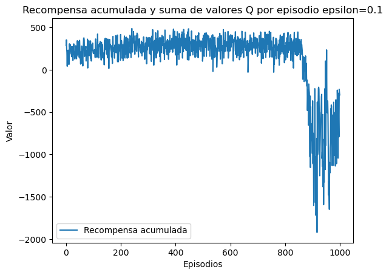

```
Q-values for epsilon = 0.1:
Q-values for product_A:
[[ 773.48153784  759.74193059  745.30722773  762.07851906  793.95214772
   744.63526599  712.51495328  679.2617166   734.07834299  763.09885757
   742.54354157]
 [ 818.87684319  804.07376114  543.37627656  708.5328829   777.64161172
   651.02496121  649.32791331  482.42665211  572.99482224  552.00566659
   425.97096833]
 [ 853.4133496   835.07470644  691.14939685  784.14437113  852.0492391
   676.5996112   772.64135887  469.27020767  584.92427387  709.13797469
   673.07546346]
 [ 821.30841725  813.80088065  683.31830739  726.14432775  849.15653236
   764.25374752  612.75700341  724.21980737  722.62138668  660.70811268
   641.23900441]
 [ 601.3392227   617.51703741  605.73986314  657.58439101  611.69730459
   629.70205936  639.04049925  638.69415898  621.90589827  675.55085253
   659.57545394]
 [ 620.85358552  571.54221708  609.92840654  583.0483577   477.28556672
   541.24273603  586.80105462  610.05520504  592.68043121  513.14225316
   604.53992491]
 [ 530.75208657  598.62035861  342.16586536  513.3196422   608.90577968
   351.95475547  612.70833443  576.36898504  479.76577591  451.66509461
   612.00189967]
 [ 398.41438019  504.83087753  503.94035008  565.21851186  557.40509447
   394.18187394  443.902559    455.55953854  543.97335664  431.95162575
   567.18727794]
 [-598.9932323  -621.45746577 -667.94585181 -592.659084   -608.73794022
  -676.1434735  -609.01505406 -616.53600101 -658.1740027  -645.88396058
  -608.07086307]
 [-365.5138164  -360.48609711 -399.64744042 -515.31815611 -338.67975816
  -343.19052121 -317.40033629 -363.95646637 -450.94932726 -507.8854817
  -398.41668806]
 [-373.24319091 -380.52595353 -395.58630405 -383.07233251 -455.3691237
  -390.47512356 -397.51354238 -425.22826048 -534.71890289 -467.36209236
  -426.96447665]]
Q-values for product_B:
[[ 647.88885051  813.94166445  836.80413295  827.93615719  797.16628956
   807.6690895   805.35633515  773.19722046  785.48267907  794.47868581
   784.01438785]
 [ 910.04771497  858.60517956  848.60412226  847.38091112  752.98785219
```

[output cut: 14 more lines]

```
 [ 439.06653123  615.21975303  630.60600176  403.51420717  639.86961414
   415.72509933  553.83589143  472.99098591  567.03187808  594.780475
   552.93052803]
 [ 418.12708382  471.47128235  457.13634504  546.16861628  470.17667829
   495.88342447  432.57459738  511.02060844  525.77468036  461.5026385
   448.99936827]
 [-575.08789436 -545.65169783 -585.12865263 -598.6877202  -590.97103045
  -662.89463476 -568.65968175 -611.67716068 -612.66947117 -647.38141009
  -612.73996559]
 [-539.11199174 -586.74440627 -532.66489975 -580.24831658 -620.98288888
  -616.38664693 -569.75915679 -626.14024919 -574.30353878 -547.1671603
  -547.9979466 ]
 [-541.48865012 -542.51640728 -550.44363566 -565.50055486 -524.74005067
  -541.31861567 -522.79090252 -491.37254273 -569.07767476 -543.17590601
  -638.32797142]]
```

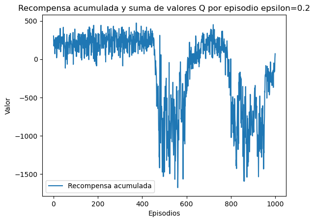

```
Q-values for epsilon = 0.2:
Q-values for product_A:
[[  687.54515205   694.89655838   682.03149557   685.99604662
    706.48463879   641.93504456   668.28530901   707.03008562
    684.16878303   661.21525491   619.64873546]
 [  670.03728499   588.48667381   620.17081392   665.34685852
    666.3720901    547.10565122   631.97139564   539.87311262
    492.88039792   580.68051513   501.26442372]
 [  664.2111273    540.34887246   566.49932107   550.12965818
    564.24915403   367.05951961   539.20392354   476.42626817
    456.33930759   416.11172399   479.90296865]
 [  725.32104409   457.05091343   597.87383442   643.49831474
    667.20590705   448.84121435   627.04694028   421.18725981
    505.75754102   591.65114205   614.30944228]
 [  683.74224737   583.12700558   533.096076     526.00698358
    625.03584535   534.3045684    545.97093424   545.44826123
    538.46130263   415.92840635   523.84808162]
 [  583.75553444   560.23162167   539.30231798   574.55967757
    593.81662935   458.9773884    538.04346393   560.29995696
    525.41905387   520.0722612    527.75215077]
 [  322.29281737   465.70308264   423.39466292   358.62329026
    404.15543469   431.77886646   386.06742267   265.22010757
    430.68380659   340.19578079   384.59470498]
 [  243.69988482   370.02708046   328.85014778   242.41932406
    340.96091322   323.6158368    271.88717938   307.98127873
    185.09460561   185.65308801   357.67735686]
 [ -487.40071519  -616.29112074  -557.07927734  -270.67417168
   -703.54363162  -672.82430553  -944.28678719  -636.58221683
   -785.09938804  -843.94133778  -712.14722087]
 [ -835.82399675  -834.1686077   -645.34521017  -466.12339089
   -755.06723522  -860.66988174 -1094.43390964  -772.73357429
   -924.0923229  -1018.5543156   -859.4379009 ]
 [ -586.39189563  -753.47697068  -453.16011547  -422.88596907
   -631.9214538   -611.1400033   -667.92327273  -620.94360878
   -725.78677866  -655.3866181   -644.4438397 ]]
Q-values for product_B:
[[  768.12542594   651.06527439   741.73540161   702.21393087
    746.51625836   643.04907591   692.92832816   643.5902109
    640.62731386   626.16683335   638.34661393]
 [  716.83966871   669.01037519   779.49852729   727.36486186
```

[output cut: 14 more lines]

```
 [  334.36315535   367.80482053   343.09203959   356.43909774
    327.71059129   353.1445781    300.38729771   259.95643457
    353.4813786    345.03010417   359.64405342]
 [  237.7701487    231.22108895   231.2866831    259.72729604
    199.68303123   238.18110753   242.25833283   208.89764262
    165.04753171   197.11585867   246.58509741]
 [ -324.21157188  -384.15066725  -468.7508373   -498.63393115
   -698.98944145  -581.99381446  -546.32359811  -728.96569215
   -582.2289458   -795.01082892  -843.60821375]
 [ -673.1287699   -973.71269879  -801.6630824   -862.25860075
  -1008.84411885  -791.28509004  -823.84881629  -918.11054392
   -831.72363041 -1029.05463813  -973.75855199]
 [ -695.72703768  -855.79705454  -810.63228735  -986.33299368
   -927.92934472  -860.99203842  -888.35952549  -992.93160065
   -892.30891616 -1046.93904041 -1039.75082185]]
```

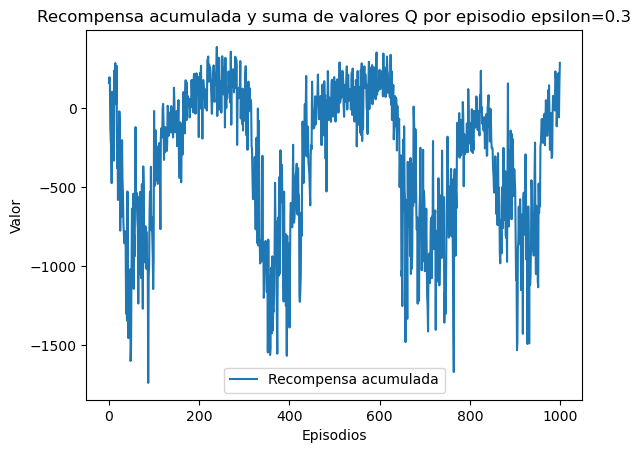

```
Q-values for epsilon = 0.3:
Q-values for product_A:
[[ 231.76385015  308.85401876  379.7874147   313.55437417  379.80423968
   310.62681491  246.06548605  307.34654133  304.51143571  276.79548727
   208.59767797]
 [ 296.43707912  436.77556275  422.3964123   373.57012194  453.37808768
   325.96212185  308.3119465   273.66869768  327.20882794  358.44653662
   306.07111987]
 [ 447.32925274  329.80922485  306.23287894  329.50499381  212.66219088
   312.80759649  351.23232811  312.32649275  221.45973347  294.66739177
   255.38880076]
 [ 490.24073407  308.45378326  215.9367251   220.5147486   172.5181056
   212.81535785  141.3783068   177.75333699  134.15475441  216.81259972
   174.54662703]
 [ 385.11284227  347.60794719  150.03537146  252.37957305  296.49029154
   234.72701501  228.9569924   272.58735591  311.60197987  124.53193158
   220.76681108]
 [ 299.2613103   300.98717653  264.73726181  299.01675039  265.43745032
   210.92089331  191.42976495  272.41933364  201.55160377  262.32354977
   238.71791656]
 [ 408.17333585  227.41047476  238.65857062  291.8988241   261.67206322
   269.27555643  185.31918186  235.65481289  250.29262487  264.01775902
   182.03207234]
 [  84.89040084   56.32650007   63.13534219   90.53035283   70.29626633
    71.70236931   46.27233359   48.50440505   71.30596022   31.02663343
    58.20375999]
 [  29.68230873 -217.02300206 -425.26518144  -29.65620536 -386.6220453
  -134.68288881 -378.54044629 -329.63284908 -200.92090932 -355.37549736
  -289.38718228]
 [-331.89386602 -639.42893398 -806.98732563 -595.82220574 -618.21560024
  -639.36016754 -835.9136589  -869.75980697 -718.52557713 -903.54343898
  -857.08695062]
 [-540.79218123 -772.62419925 -851.72158181 -651.60157558 -702.1297405
  -734.87983777 -820.27392155 -740.83551036 -708.40963502 -759.66881872
  -730.89165046]]
Q-values for product_B:
[[ 481.55123915  515.92463994  513.93576991  515.50999619  461.910967
   441.39301125  440.35594424  413.53056467  412.6994001   435.06579111
   381.62228236]
 [ 448.13274959  358.93125424  403.66526399  377.45294174  192.52149152
```

[output cut: 14 more lines]

```
 [ 350.71716986  306.09610467  238.03129402  278.4243276   227.77799945
   246.72710283  243.78051937  201.81573557  221.21286851  215.7032634
   238.71115349]
 [  51.53688348   38.11607793   18.97660417   46.61514147  -53.04259317
    33.00399018  -13.71821434   38.05045623  -47.06777382  -23.13855816
    35.97260541]
 [ -48.11175912 -225.31364013 -445.13510598 -521.19179751 -342.71507465
  -385.02904363 -461.63853099 -581.59531701 -458.15857042 -537.78622699
  -494.20658756]
 [-261.10714266 -341.33188079 -639.9688208  -597.27465799 -543.78680388
  -633.75772678 -515.0394586  -773.03959285 -883.63187076 -561.75675696
  -821.01900298]
 [-730.11414902 -882.32727136 -863.16008239 -921.13551979 -928.70498192
  -860.74129322 -889.36839751 -957.21784042 -960.83567174 -945.69284949
  -914.53671827]]
```

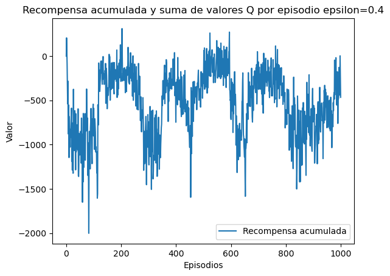

```
Q-values for epsilon = 0.4:
Q-values for product_A:
[[ 5.29331470e+01 -2.30028767e+00  0.00000000e+00  1.20014224e+01
   8.28696215e+00  9.71641767e-02 -2.76211970e+00  3.88570556e-01
   0.00000000e+00 -2.92806012e+00 -2.78252519e+00]
 [ 0.00000000e+00  0.00000000e+00  0.00000000e+00  0.00000000e+00
   0.00000000e+00  0.00000000e+00  0.00000000e+00  0.00000000e+00
   0.00000000e+00  0.00000000e+00  0.00000000e+00]
 [-1.97455695e+01 -2.06191277e+01 -1.35477079e+01  0.00000000e+00
   0.00000000e+00 -1.28411709e+01 -3.68132900e+00 -3.97423505e+01
  -2.25329743e+01 -8.46629524e+00 -8.74147409e+00]
 [ 1.35953004e+02  5.69587938e+01  6.98035762e+00  2.57239378e+01
   4.48655377e+00 -1.36213246e+01  2.13176450e+01 -1.96832981e+01
   1.97420406e+00 -6.93679293e+01  1.08018093e+01]
 [-2.33952571e+01 -2.60653380e+01 -5.55696512e+01 -4.68695671e+01
  -3.35978737e+01 -2.41270377e+01 -5.50517889e+01 -4.32288500e+01
  -2.70022063e+01 -2.15014384e+01 -6.35498300e+01]
 [-1.22070272e+02  4.73601552e+00 -5.14726102e+01 -1.41204324e+01
  -3.16302645e+01 -3.30138693e+01  3.35378191e+00 -1.27767925e+01
  -1.08073001e+01  1.23594232e+01 -4.84006541e+01]
 [-1.78140803e+02 -2.17491010e+02 -1.73676699e+02 -2.37542989e+02
  -1.62110681e+02 -2.06567087e+02 -1.80699872e+02 -2.24671239e+02
  -1.92649024e+02 -1.72589274e+02 -1.73754823e+02]
 [-3.06946251e+02 -3.25043976e+02 -2.68001956e+02 -3.18637736e+02
  -2.84867899e+02 -3.38919366e+02 -3.46118732e+02 -3.25494086e+02
  -3.24563610e+02 -4.01185198e+02 -3.41831914e+02]
 [-1.00514017e+03 -7.51212482e+02 -8.92265005e+02 -9.63523387e+02
  -9.03511468e+02 -9.66018314e+02 -9.00664475e+02 -1.13270019e+03
  -9.55738647e+02 -9.18223615e+02 -1.00279271e+03]
 [-1.05401504e+03 -7.31974410e+02 -1.03451064e+03 -1.04192042e+03
  -1.06215541e+03 -9.85610567e+02 -1.18466900e+03 -1.15746552e+03
  -1.16835011e+03 -1.13536104e+03 -1.10282102e+03]
 [-1.25490726e+03 -1.04651296e+03 -1.19649351e+03 -1.21917439e+03
  -1.12473730e+03 -1.22672209e+03 -1.19519840e+03 -1.23948233e+03
  -1.22268403e+03 -1.22819783e+03 -1.23608235e+03]]
Q-values for product_B:
[[  209.89783171   109.46728281    55.46495299    64.9893988
     48.26309532    65.33820134    59.49301165    47.05829759
     18.87289303    28.91471399    38.53140853]
 [   34.91262021    24.82223664    18.70882582     0.
```

[output cut: 14 more lines]

```
 [ -157.53733369  -163.03907156  -102.40632521  -137.38864325
    -49.33966502   -90.16588315   -96.14950656   -73.66586934
   -164.26430787   -96.63245433   -61.9973233 ]
 [ -423.68293237  -404.12125001  -407.87875877  -416.40804031
   -422.22685621  -387.20174717  -426.43435257  -410.43109398
   -382.05866434  -404.23126864  -481.06029438]
 [-1009.41073598  -935.74335681  -736.49908097  -944.36502261
   -972.68030694 -1039.88423968 -1005.03123089  -894.28835298
   -993.07907752  -907.54933313  -981.6118843 ]
 [ -762.55274846  -915.63347829  -752.63163555  -874.39335482
   -929.74963331  -973.87367726  -979.78918893 -1039.27512521
   -988.22674439 -1080.40658334 -1000.53120313]
 [-1146.19614031 -1159.48197379  -913.07319197 -1071.46188275
  -1188.56519491 -1208.24511866 -1097.75618954 -1190.46508757
  -1155.19476426 -1227.46795828 -1269.81160046]]
```

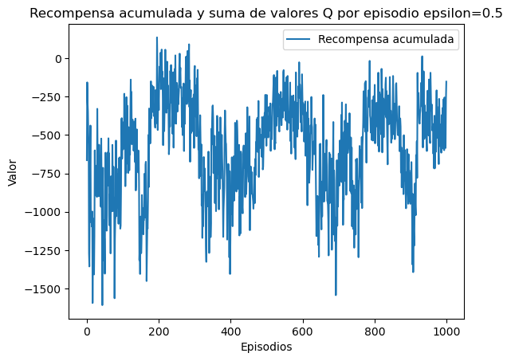

```
Q-values for epsilon = 0.5:
Q-values for product_A:
[[    0.             0.             0.             0.
      0.             0.             0.             0.
      0.             0.             0.        ]
 [    0.             0.             0.             0.
      0.             0.             0.             0.
      0.             0.             0.        ]
 [    0.             0.             0.             0.
      0.             0.             0.             0.
      0.             0.             0.        ]
 [   16.1444578    -23.48767311   -67.40273951   -36.86070885
    -66.32415368   -79.41353726   -45.65107765   -84.19401941
    -14.99745975   -14.3077148    -94.61902949]
 [  -31.41620325   -10.69884007   -26.58790124   -27.70968169
    -33.11767732   -34.32251226   -44.82532306   -23.79425964
    -32.23177629   -58.89702024   -13.81924127]
 [  -87.96556086   -21.65588186   -53.49894148  -135.15861471
    -14.64816259   -96.17672984  -114.51701167  -101.97452056
    -55.90903445   -63.1017394   -105.65028758]
 [ -337.88686876  -283.05884465  -295.09212246  -274.78776868
   -306.3691369   -290.62221328  -277.26918628  -320.76980016
   -323.74188267  -289.69844293  -315.76463267]
 [ -540.80920694  -536.57457909  -544.66615061  -547.27628297
   -558.18158762  -538.29680067  -538.6141062   -585.18063578
   -546.1854999   -584.57985988  -590.33529118]
 [ -787.11824563  -783.44771092  -771.93772466  -830.38134878
   -819.37982643  -835.34144291  -833.91069997  -824.57847899
   -847.2043015   -843.18914483  -861.74501248]
 [ -777.40173824  -730.11432628  -740.37831019  -782.69578466
   -743.71543177  -792.37984447  -789.30215246  -811.27490624
   -794.20136675  -797.37050606  -798.83735424]
 [-1001.37429925 -1001.05116217 -1007.6883837  -1006.8804856
  -1035.85705359 -1041.42627569 -1014.01654001 -1040.36812799
  -1035.36578513 -1028.82051178 -1039.60265826]]
Q-values for product_B:
[[-4.62100171e+01 -2.11744882e+01 -1.53072286e+01 -1.04442217e+01
  -1.00530570e+01 -8.19823084e+00  0.00000000e+00 -1.71629496e+00
  -1.45844996e+01 -1.43864902e+01 -1.68311991e+01]
 [-1.74312751e+01  7.86804643e-01  0.00000000e+00  0.00000000e+00
```

[output cut: 14 more lines]

```
 [-3.09022261e+02 -2.78729898e+02 -2.86468466e+02 -3.10313380e+02
  -3.18857595e+02 -2.78265616e+02 -3.20556554e+02 -3.05773584e+02
  -3.14977537e+02 -3.26836340e+02 -3.59923779e+02]
 [-5.85554427e+02 -5.84731381e+02 -5.66142549e+02 -5.72462901e+02
  -5.05296007e+02 -5.63145796e+02 -5.30415083e+02 -5.76197125e+02
  -5.58384544e+02 -5.70613844e+02 -5.87135245e+02]
 [-7.01094975e+02 -7.04035328e+02 -7.15540906e+02 -7.02045058e+02
  -7.26475273e+02 -7.53520898e+02 -7.34306457e+02 -7.37988512e+02
  -7.31460520e+02 -7.47587084e+02 -7.56680440e+02]
 [-6.80005811e+02 -7.53405650e+02 -7.33766867e+02 -7.98408897e+02
  -7.32170800e+02 -7.46804661e+02 -7.69233874e+02 -7.60607294e+02
  -7.77909823e+02 -7.69622033e+02 -8.00052253e+02]
 [-9.78275386e+02 -9.08839819e+02 -1.00200219e+03 -9.56924901e+02
  -1.01183137e+03 -9.80316216e+02 -1.03572075e+03 -1.01702104e+03
  -1.04748555e+03 -1.02489571e+03 -1.04455056e+03]]
```

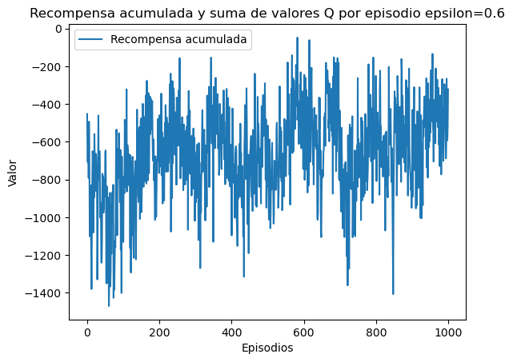

```
Q-values for epsilon = 0.6:
Q-values for product_A:
[[    0.             0.             0.             0.
      0.             0.             0.             0.
      0.             0.             0.        ]
 [    0.             0.             0.             0.
      0.             0.             0.             0.
      0.             0.             0.        ]
 [    0.             0.             0.             0.
      0.             0.             0.             0.
      0.             0.             0.        ]
 [    0.             0.             0.             0.
      0.             0.             0.             0.
      0.             0.             0.        ]
 [  -71.46166501   -79.25082935  -109.26790692   -96.18614223
    -71.30763571   -61.44068496   -46.04296255    -2.92084
    -57.10561469   -61.22350172   -58.88570459]
 [ -133.09665657   -92.86699995  -114.95842603  -106.95963451
    -80.06042935  -117.63168178   -96.98777735  -117.91022842
   -125.68278061  -124.09434195   -95.75203078]
 [ -455.16501631  -446.06266983  -432.56591543  -433.47622919
   -409.07076441  -406.590537    -436.21202964  -461.00761519
   -425.53800208  -483.29959421  -439.43950819]
 [ -824.0062131   -811.06465997  -833.41592565  -824.34646444
   -831.0077221   -823.70628255  -831.38191695  -820.75374775
   -834.28102991  -810.04131195  -837.8280799 ]
 [ -994.56677253  -969.78167645 -1015.40470509  -992.43990178
  -1004.06656604  -984.75981014  -997.64353156  -987.58360372
  -1012.37535666  -985.87271026 -1030.36653986]
 [ -952.50583381  -950.91166137  -953.58000051  -982.04748431
   -979.3575144   -995.75475985  -971.96499608  -997.11232346
  -1002.40902851 -1017.50535917 -1014.68616251]
 [ -965.89075993  -970.14774614  -973.44854367  -997.15138569
   -988.42785556 -1019.18362036  -995.30384018 -1023.38785023
  -1022.2024133  -1006.05105615 -1087.94034149]]
Q-values for product_B:
[[    0.             0.             0.             0.
      0.             0.             0.             0.
      0.             0.             0.        ]
 [    0.             0.             0.             0.
```

[output cut: 14 more lines]

```
 [ -471.9979721   -452.44256806  -467.81224629  -440.41870476
   -415.05380952  -429.67511959  -450.94597013  -474.03741205
   -441.73139633  -479.34445293  -499.43608613]
 [ -809.97396322  -791.72598035  -814.91002506  -829.43075725
   -855.81991087  -847.94949465  -870.46855242  -821.75199251
   -829.73580194  -870.23360583  -876.89951062]
 [ -844.43636285  -856.15163058  -855.46377676  -872.56441703
   -866.55215993  -934.12388354  -949.7133103   -945.59651978
   -974.22593754  -939.34303745  -953.71396052]
 [ -980.27241917  -969.2807045  -1012.28222579  -974.88731838
  -1011.69020837  -975.43902352 -1012.75874918 -1047.75926563
  -1017.39875115 -1045.4511107  -1033.39333311]
 [-1047.12197937 -1036.30305294 -1043.63624383 -1064.14660915
  -1070.41484657 -1085.20764696 -1078.04296714 -1071.23877916
  -1078.26226153 -1073.37603601 -1096.40554784]]
```

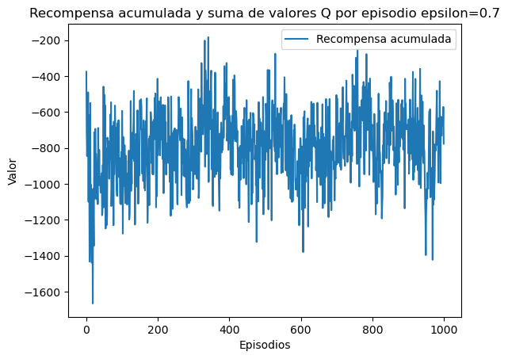

```
Q-values for epsilon = 0.7:
Q-values for product_A:
[[    0.             0.             0.             0.
      0.             0.             0.             0.
      0.             0.             0.        ]
 [    0.             0.             0.             0.
      0.             0.             0.             0.
      0.             0.             0.        ]
 [    0.             0.             0.             0.
      0.             0.             0.             0.
      0.             0.             0.        ]
 [    0.             0.             0.             0.
      0.             0.             0.             0.
      0.             0.             0.        ]
 [    0.             0.             0.             0.
      0.             0.             0.             0.
      0.             0.             0.        ]
 [  -35.04880389   -23.90761069     6.580289     -19.72751961
     -8.02449217     0.            -7.48511031   -30.76636297
    -16.37664648     0.           -14.87242674]
 [ -382.23486428  -385.20019428  -398.1933984   -349.23200062
   -387.71137055  -319.78915839  -392.84180598  -416.39082374
   -378.47599059  -447.18696182  -394.72163354]
 [-1041.37793906 -1031.51355724 -1029.72103544 -1024.71962795
  -1019.43097508 -1023.02497042 -1026.90920705 -1048.63672693
  -1039.78517915 -1015.49231881 -1024.9703296 ]
 [-1520.60544271 -1528.72296857 -1531.54507876 -1552.54378299
  -1582.08512268 -1541.90251289 -1515.40456888 -1521.61348927
  -1570.42836355 -1589.82150857 -1596.57648933]
 [-1384.88620497 -1390.66759108 -1439.08036808 -1413.87479625
  -1399.54767371 -1421.49903353 -1400.99612587 -1413.64248311
  -1437.6271031  -1428.56175876 -1436.077921  ]
 [-1564.17896267 -1596.39548004 -1595.45503008 -1625.23209156
  -1598.61808242 -1636.60606631 -1611.64665912 -1608.96864433
  -1637.70862662 -1601.425875   -1624.03286394]]
Q-values for product_B:
[[    0.             0.             0.             0.
      0.             0.             0.             0.
      0.             0.             0.        ]
 [    0.             0.             0.             0.
```

[output cut: 14 more lines]

```
 [ -446.13896058  -467.19594183  -367.6657435   -429.81911471
   -422.9375836   -441.32128971  -357.79656171  -410.88721515
   -425.39522816  -449.95862219  -406.30017867]
 [ -922.86105079  -946.07738944  -922.31747786  -952.01898989
   -924.12108601  -901.36936431  -962.02333926  -944.43362689
   -953.15169145  -982.86028158 -1007.88231309]
 [-1371.76611822 -1339.76023393 -1371.91371921 -1357.88170865
  -1399.46133827 -1373.36018342 -1397.58095297 -1370.50684899
  -1394.84392675 -1403.91949193 -1393.45047281]
 [-1544.68292338 -1518.14680137 -1499.05231316 -1505.78535274
  -1548.35507342 -1548.02877541 -1577.49220754 -1563.43674827
  -1585.87048264 -1606.34408899 -1592.18858074]
 [-1505.48239038 -1556.77039758 -1550.35883848 -1594.76426112
  -1604.40920874 -1579.48978436 -1605.79381504 -1589.63482913
  -1607.0475902  -1642.41621433 -1627.47392464]]
```

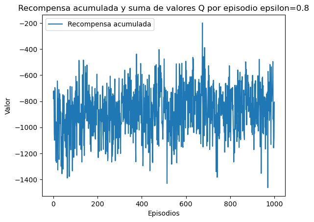

```
Q-values for epsilon = 0.8:
Q-values for product_A:
[[    0.             0.             0.             0.
      0.             0.             0.             0.
      0.             0.             0.        ]
 [    0.             0.             0.             0.
      0.             0.             0.             0.
      0.             0.             0.        ]
 [    0.             0.             0.             0.
      0.             0.             0.             0.
      0.             0.             0.        ]
 [    0.             0.             0.             0.
      0.             0.             0.             0.
      0.             0.             0.        ]
 [   -5.0905       -21.72989259   -34.58526174   -12.60307777
    -58.31798817   -95.18872032   -22.23365779   -36.64609949
    -47.62374893   -69.27208199   -81.00975407]
 [  -79.37767367   -37.81253435   -45.43554613     0.
    -36.86197929  -101.31118406   -66.77966526   -56.07990923
     -5.727          0.           -73.71149516]
 [ -478.72405413  -485.51454834  -539.33502572  -477.98389355
   -466.32255089  -500.72230595  -423.12754528  -517.55653173
   -516.37798549  -526.3078239   -508.25639121]
 [-1081.293923   -1065.9243797  -1047.14600345  -996.37303067
  -1023.58047612 -1030.16686337 -1007.0415103  -1053.45266732
  -1034.09221066 -1041.62617689  -998.46358346]
 [-1603.16273194 -1629.5815857  -1541.33718547 -1631.11935281
  -1595.75401621 -1643.60810154 -1639.43685673 -1647.02417721
  -1617.74075212 -1602.18558938 -1655.56427827]
 [-1550.07488445 -1587.16172003 -1585.41578607 -1539.47124512
  -1604.47954438 -1610.37380333 -1586.915101   -1585.2963621
  -1566.61368963 -1600.6295516  -1660.86841814]
 [-1809.14765936 -1767.15520678 -1776.72966084 -1772.41380993
  -1774.58976639 -1793.23378916 -1790.45166482 -1779.163754
  -1798.69308195 -1829.23999847 -1821.01183677]]
Q-values for product_B:
[[    0.             0.             0.             0.
      0.             0.             0.             0.
      0.             0.             0.        ]
 [    0.             0.             0.             0.
```

[output cut: 14 more lines]

```
 [ -723.61678954  -780.8362483   -733.31606769  -745.65248407
   -731.93008378  -724.86033949  -782.51993866  -729.77039812
   -718.67095878  -777.4899083   -754.25605542]
 [-1133.84504552 -1130.28675108 -1144.84296569 -1133.89507681
  -1135.7097113  -1102.72226639 -1142.09283463 -1163.23282338
  -1157.95692452 -1146.92618725 -1136.00396512]
 [-1556.94056479 -1539.06013506 -1530.25425481 -1548.45439129
  -1541.91088439 -1565.72435711 -1588.48719788 -1574.39759685
  -1576.52489472 -1589.877392   -1612.19093119]
 [-1543.56869498 -1478.41244513 -1567.64675008 -1571.4441597
  -1583.11793304 -1614.078796   -1619.59838068 -1638.06637278
  -1600.69540389 -1623.77132431 -1645.26064367]
 [-1628.23351094 -1642.23539595 -1640.02743297 -1654.05475733
  -1617.37606323 -1685.5711481  -1680.3777562  -1684.7667647
  -1674.44692587 -1710.09240086 -1708.14985715]]
```

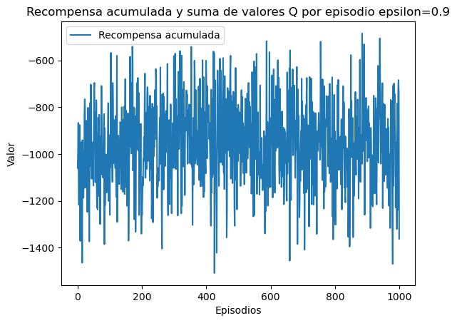

```
Q-values for epsilon = 0.9:
Q-values for product_A:
[[    0.             0.             0.             0.
      0.             0.             0.             0.
      0.             0.             0.        ]
 [    0.             0.             0.             0.
      0.             0.             0.             0.
      0.             0.             0.        ]
 [    0.             0.             0.             0.
      0.             0.             0.             0.
      0.             0.             0.        ]
 [    0.             0.             0.             0.
      0.             0.             0.             0.
      0.             0.             0.        ]
 [  -80.55307991   -95.56299545   -70.99346985     0.
    -13.4904521    -28.21100145   -39.26520178   -35.03361573
    -23.32561597   -17.11013377   -18.09912039]
 [  -88.18127404   -75.61631693  -130.08199979  -169.82114758
   -126.4510085   -134.66494145  -132.88251239  -138.51029054
   -111.67077767  -136.21096476  -107.54955966]
 [ -432.33677793  -482.73515802  -429.54807978  -487.30661597
   -473.56234184  -496.53176629  -505.53481492  -512.28982206
   -507.01610668  -453.78774223  -478.12331496]
 [-1251.12640179 -1230.63963653 -1218.0794413  -1241.14741581
  -1177.56203198 -1281.72734403 -1271.43301867 -1222.06638052
  -1276.59673581 -1220.23996155 -1306.26728769]
 [-1875.07792547 -1908.38180816 -1958.91284619 -1949.92329347
  -1945.42748641 -1933.03449232 -1946.47453983 -1965.98524737
  -1974.84170332 -1950.82762034 -1892.04767844]
 [-1901.48927294 -1910.66701179 -1931.11145335 -1888.44889691
  -1933.74458949 -1907.4222308  -1971.48289879 -1908.20615128
  -1907.20985516 -1964.44417645 -1915.04717421]
 [-1852.47582317 -1855.26296693 -1881.93428834 -1879.62417507
  -1929.40317126 -1908.66446807 -1943.03750133 -1924.199086
  -1929.1573386  -1962.70790411 -1947.67685532]]
Q-values for product_B:
[[    0.             0.             0.             0.
      0.             0.             0.             0.
      0.             0.             0.        ]
 [    0.             0.             0.             0.
```

[output cut: 14 more lines]

```
 [ -653.65041739  -659.40889042  -673.90009911  -693.78231336
   -612.59880496  -611.42906224  -677.09959627  -649.70776049
   -658.85862849  -673.78618522  -665.75070692]
 [-1099.30426585 -1179.77371031 -1152.8157422  -1119.91362054
  -1214.12979381 -1176.97329956 -1194.43696705 -1214.27584201
  -1218.39180886 -1188.91214498 -1244.49723141]
 [-1676.03419666 -1715.47471495 -1691.56084435 -1673.88246139
  -1714.38336071 -1734.80418737 -1779.66417346 -1748.61442953
  -1772.89949637 -1816.40059938 -1808.07843678]
 [-1829.76367917 -1781.21133218 -1806.21043245 -1774.6726214
  -1789.95600783 -1841.270171   -1878.85643555 -1862.41724607
  -1853.68771426 -1842.18121168 -1926.34741154]
 [-1929.49024501 -1953.9177299  -1942.60692951 -1961.46769975
  -1976.88883154 -1987.17253344 -1992.82568548 -2004.94149364
  -1968.20709258 -2018.43643492 -2088.12179295]]
```

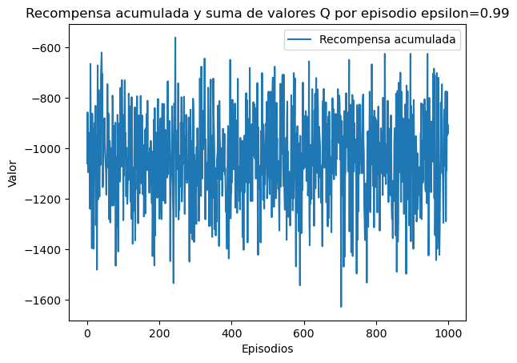

```
Q-values for epsilon = 0.99:
Q-values for product_A:
[[    0.             0.             0.             0.
      0.             0.             0.             0.
      0.             0.             0.        ]
 [    0.             0.             0.             0.
      0.             0.             0.             0.
      0.             0.             0.        ]
 [    0.             0.             0.             0.
      0.             0.             0.             0.
      0.             0.             0.        ]
 [    0.             0.             0.             0.
      0.             0.             0.             0.
      0.             0.             0.        ]
 [ -103.59480237   -44.9587874    -65.91150128   -25.35189052
    -71.97365692   -32.81958103   -69.29974119   -50.30027302
    -55.03418389   -19.543076     -46.33857144]
 [ -149.14874148  -137.27175567  -157.64415629  -137.38377966
   -187.58720423  -173.85296344   -85.83330044  -158.03317614
   -155.39736901  -147.27937188  -179.14412133]
 [ -472.66486136  -380.05011767  -472.37378746  -474.32262778
   -475.81701202  -481.04117697  -490.56260165  -447.15046528
   -490.44068699  -435.41269778  -581.71255108]
 [ -780.83801741  -792.08639379  -853.74927466  -839.70266965
   -932.80081868  -860.81190835  -778.05207272  -795.76878525
   -819.51495999  -869.20294352  -831.75198101]
 [-2092.52809337 -2048.38355361 -2041.29146265 -2068.88730176
  -2060.35216139 -2069.15455663 -2077.37719414 -2119.29701216
  -2092.8865627  -2117.38911906 -2110.74024691]
 [-1968.73148684 -1974.01175897 -2015.70284814 -1987.93714208
  -2011.66088188 -2004.69463279 -1992.1017536  -2037.25260176
  -2022.35028943 -1993.37643458 -2031.87084071]
 [-2043.5230978  -2052.64500831 -2059.51089495 -2064.94267067
  -2096.4642438  -2060.08766836 -2089.51210357 -2071.20466424
  -2063.69253071 -2119.5828157  -2104.27893067]]
Q-values for product_B:
[[    0.             0.             0.             0.
      0.             0.             0.             0.
      0.             0.             0.        ]
 [    0.             0.             0.             0.
```

[output cut: 14 more lines]

```
 [ -629.67236092  -616.43646262  -590.56337378  -652.66220968
   -611.53277578  -673.53235009  -651.65346201  -677.48521996
   -722.10902415  -609.22007263  -706.43854313]
 [-1028.93687197 -1035.27617908 -1028.72750348 -1043.82895241
  -1066.86878578 -1092.00395677 -1058.12576048 -1099.98644038
  -1045.35893733 -1081.57114224 -1074.26124237]
 [-1939.8305349  -1910.66001163 -1920.82252834 -1950.18498851
  -1922.62729359 -1938.55606473 -1944.48218464 -1909.15173097
  -1963.87053246 -1985.96088652 -1983.8067331 ]
 [-2076.02914496 -2097.14985953 -2111.48217885 -2112.16597401
  -2106.81591403 -2127.50048972 -2120.12846619 -2094.47755017
  -2101.01933725 -2113.85771091 -2180.03759883]
 [-2049.70693192 -2098.49768746 -2080.71299258 -2070.61153359
  -2077.32991996 -2118.07876897 -2093.86847322 -2113.41505091
  -2113.82540251 -2126.48124975 -2141.63389866]]
```

```python
epsilons = [0.1, 0.2, 0.3, 0.4, 0.5, 0.6, 0.7, 0.8, 0.9, 0.99]
env = InventoryEnvironment()

for eps in epsilons:
    Q_values = q_learning(env, num_episodes=1000, epsilon=eps)
    print(f"Q-values for epsilon = {eps}:")

    for product in env.products:
        print(f"Q-values for {product}:")
        print(Q_values[product])
```

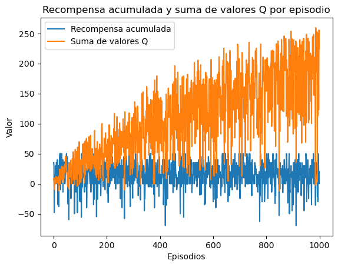

```
Q-values for epsilon = 0.1:
Q-values for product_A:
[[ 1.40566816e+02  2.57900000e+00  1.54306147e+01  0.00000000e+00
   0.00000000e+00  0.00000000e+00  0.00000000e+00  0.00000000e+00
   0.00000000e+00  0.00000000e+00  0.00000000e+00]
 [ 1.29045604e+02  2.68408351e+00  0.00000000e+00  0.00000000e+00
   0.00000000e+00  0.00000000e+00  0.00000000e+00  0.00000000e+00
   0.00000000e+00  0.00000000e+00  0.00000000e+00]
 [ 1.03237756e+02  0.00000000e+00  3.56385483e+00  0.00000000e+00
   0.00000000e+00  0.00000000e+00  0.00000000e+00  0.00000000e+00
   0.00000000e+00  0.00000000e+00  0.00000000e+00]
 [ 1.22302967e+02  1.74879455e+01  0.00000000e+00  7.70000000e-01
   0.00000000e+00  0.00000000e+00  0.00000000e+00  0.00000000e+00
   0.00000000e+00  0.00000000e+00  0.00000000e+00]
 [ 1.00842066e+02  2.43364534e+01  0.00000000e+00  1.87602128e+00
   0.00000000e+00  4.10860679e+00  0.00000000e+00  0.00000000e+00
   0.00000000e+00  0.00000000e+00  0.00000000e+00]
 [ 8.50205512e+01  5.40997745e+01  0.00000000e+00  0.00000000e+00
   1.20942687e+01  4.50450579e+00  0.00000000e+00  0.00000000e+00
   0.00000000e+00  0.00000000e+00  0.00000000e+00]
 [ 6.56043081e+01  4.61891760e+01  4.37733480e+00  9.10754036e-01
   0.00000000e+00  2.85864109e+00 -2.16406285e+00  1.92243416e+00
   4.30181839e+00  0.00000000e+00  0.00000000e+00]
 [ 8.72516660e+01  5.83424100e+01  0.00000000e+00  0.00000000e+00
   0.00000000e+00  0.00000000e+00  0.00000000e+00  5.87815340e+00
   0.00000000e+00  8.82203308e-01  0.00000000e+00]
 [ 9.53530368e+01  7.48959055e+01  6.16060211e+00  7.09980254e+00
   1.53853671e+01  4.92399609e+00 -6.30685000e-02  6.78164564e+00
   1.01847250e+01  2.13535836e+01  6.73689317e+00]
 [ 3.32891596e+01  1.73346509e+01  6.37857164e+00  0.00000000e+00
   2.28779052e+00  4.16781260e+00  1.84262174e+00  9.33461272e-01
   1.13595367e+00  1.71086963e+00 -3.34641511e+00]
 [ 7.63272528e+00 -1.00870982e+00  0.00000000e+00 -9.54086125e-01
  -1.31305472e+00 -9.91373519e-01 -2.91938234e+00 -8.09940237e+00
  -7.25387599e+00 -1.38050028e+01 -1.36479368e+01]]
Q-values for product_B:
[[121.66550625  11.61343178   6.40781212   0.           0.
    0.           0.           0.           0.           0.
    0.        ]
 [126.77191956  12.26116671   0.           0.           0.
```

[output cut: 14 more lines]

```
 [ 84.14816012   5.30746716   4.4791434    5.48469209   0.
    0.           0.           0.           5.99200556   0.
    0.        ]
 [112.13814919  10.53014054   0.           4.24359885   0.
    0.          12.07425101   0.           0.           0.40815245
    0.        ]
 [103.09624973  20.77550617   5.9337888    6.26377543   0.
   14.30650805  12.15479317  14.63057106   3.69521022   7.21885653
    6.09965907]
 [ 57.20570847   1.8382652    3.15108761   0.          -3.84586993
    2.85742301   1.14580358  -1.9387597   -1.81551003 -13.10116341
   -7.11948093]
 [ 10.36430881  -1.26721221   0.          -4.27967532  -0.98346028
   -0.77137967   0.           0.          -9.7301624   -5.60815058
  -20.54717263]]
```

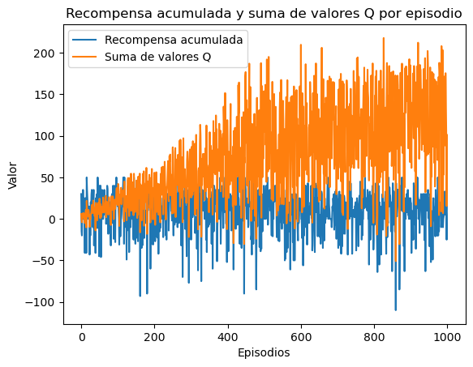

```
Q-values for epsilon = 0.2:
Q-values for product_A:
[[ 94.35743692  11.15894481   0.           0.           0.
    0.           0.           0.           0.           0.
    0.        ]
 [ 90.23910037  21.54808572   0.           4.89832099   0.
    0.           0.           0.           0.           0.
    0.        ]
 [ 56.78395256   5.79332853   3.0472951    0.           0.
    0.           0.           0.           0.           0.
    0.        ]
 [ 60.28813222   5.95253095   9.03326344   0.79043351   1.18149036
    6.3267339    0.           0.           0.           0.
    0.        ]
 [ 74.12424381  10.43102819   3.76173915  20.4093073    4.63173923
    8.40356382   0.           0.           0.           0.
    0.        ]
 [ 75.68075681   7.21037128  -0.40947053  13.53997768  11.47247392
    4.01704165   7.98267621   1.47980262   0.           0.
    0.        ]
 [ 80.82342414  10.51074076   6.92121171   2.03188211   2.65217352
   -0.95147659   1.05675159   1.34868846   4.44135959   0.
    0.        ]
 [ 68.03216808  21.68726258   6.88144874   2.41938319   0.
    3.30097264   0.2510338    0.           1.01857651   1.33971858
    0.        ]
 [ 63.31324859  47.7313138    0.          21.35902893  24.04492849
    0.          14.84823615  14.93744603   4.013397    13.86101618
    1.6453488 ]
 [  7.0430779   12.58806276  -3.15982244   0.42360442   4.2103345
   -3.85037416  -3.98466879  -4.0075156   -3.75060188 -12.94843387
  -16.29528995]
 [ 21.52421719  10.98376828   0.           1.95935253 -11.14866653
   -1.53096754   1.59086544  -7.78661072   0.         -21.20597485
  -16.05350108]]
Q-values for product_B:
[[114.23321156   7.61723994  11.69979215   0.           0.
    0.           0.           0.           0.           0.
    0.        ]
 [ 99.89636779   9.63278829   2.14613933   0.           0.
```

[output cut: 14 more lines]

```
 [ 46.08309099  35.7415368   10.11744649  11.62856487  -4.165
   -0.20535076  -2.31795181   4.24747819   0.           0.
    0.        ]
 [ 27.7783001   52.4096397    0.           0.           3.68070331
    7.67541508  -6.36607901  -1.12785228  -3.01503258   0.
    0.        ]
 [ 55.40915986  78.32642696  23.31739476  20.31108877   5.05543319
   32.89172788  12.51062976   7.10171042  11.22781223  14.30542562
   -9.20996543]
 [ 12.92184712  26.84683053  12.10983317   1.31962376  -0.43062924
   -0.70331933 -11.28539653  -1.99670707 -16.4507691   -5.80786253
  -22.37671796]
 [ -3.418       -6.79539934  -6.5364586   -6.74390022  -8.22661677
   -6.485       -5.97851775  -8.71762     -9.90074    -27.0663165
  -34.55211105]]
```

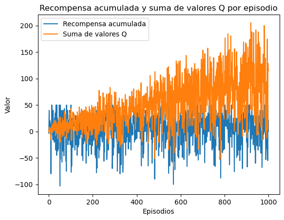

```
Q-values for epsilon = 0.3:
Q-values for product_A:
[[ 1.08946660e+02  1.87167234e+00  0.00000000e+00  0.00000000e+00
   0.00000000e+00  0.00000000e+00  0.00000000e+00  0.00000000e+00
   0.00000000e+00  0.00000000e+00  0.00000000e+00]
 [ 7.13312333e+01  7.06805096e+00  0.00000000e+00  1.14104591e+01
   0.00000000e+00  0.00000000e+00  0.00000000e+00  0.00000000e+00
   0.00000000e+00  0.00000000e+00  0.00000000e+00]
 [ 4.09104572e+01  2.75573015e-02  7.38234581e+00  5.75818158e+00
   0.00000000e+00  0.00000000e+00  0.00000000e+00  0.00000000e+00
   0.00000000e+00  0.00000000e+00  0.00000000e+00]
 [ 6.81542200e+01  1.14211524e+01  1.03651442e+01  1.45849284e+01
   1.00777128e+00  1.33098755e+01  0.00000000e+00  0.00000000e+00
   0.00000000e+00  0.00000000e+00  0.00000000e+00]
 [ 5.62674511e+01  1.32940000e+00  4.67009874e+00  2.18586830e+01
   3.46434097e+00  2.35381723e+00  1.13559494e+00  0.00000000e+00
   0.00000000e+00  0.00000000e+00  0.00000000e+00]
 [ 7.06391380e+01  1.32672679e+01  0.00000000e+00  5.85871195e+00
   6.50749274e+00  0.00000000e+00  0.00000000e+00  4.07292360e+00
   0.00000000e+00  0.00000000e+00  0.00000000e+00]
 [ 2.74632119e+01  2.15570000e+00  5.21603665e+00  3.87975742e+00
   2.21341477e+00  8.22891420e+00  1.53213856e+00  2.49451001e+00
  -2.82831093e+00  0.00000000e+00  0.00000000e+00]
 [ 3.21463289e+01  1.11215473e+01  1.13740103e+01  9.29527489e-01
  -1.44498273e+00  4.06139013e-01 -3.01901042e+00 -2.83977856e+00
   9.24166046e-01  0.00000000e+00  0.00000000e+00]
 [ 5.98386905e+01  3.14545434e+01  2.88424869e+01  1.04193937e+01
   1.07950597e+01  2.17171256e+01  1.33997226e+01  6.26733400e+00
   4.27931075e+00  1.37692628e+01  2.95204182e+00]
 [ 1.97113992e+01  1.10388234e+01  4.81236204e+00 -7.80006809e+00
  -9.57338752e-01  1.36959907e-01 -9.14608872e+00 -1.76203375e+01
  -1.78507751e+01 -2.06234694e+01 -5.39068682e+00]
 [ 1.65734005e+01  4.53701708e+00 -2.69620194e+00  3.80900698e-01
  -8.72575198e+00 -4.11890809e+00 -3.11406343e+00 -1.29135052e+01
  -1.71612471e+01 -2.87113372e+01 -2.31231790e+01]]
Q-values for product_B:
[[ 6.54476342e+01  7.64892670e+00  2.81108527e+00  0.00000000e+00
   0.00000000e+00  0.00000000e+00  0.00000000e+00  0.00000000e+00
   0.00000000e+00  0.00000000e+00  0.00000000e+00]
 [ 5.82614527e+01  3.25566485e+00  0.00000000e+00 -4.78937458e-01
```

[output cut: 14 more lines]

```
 [ 7.28597486e+01  8.00000000e-01  1.61518509e+01  1.05012629e+01
   1.95331647e+01  2.83471323e+00  1.12205924e+01  5.15644352e-01
   2.00405709e+00  0.00000000e+00  0.00000000e+00]
 [ 5.84119567e+01  1.61224333e+01  4.19563243e+00 -1.10292520e+00
  -2.09153715e+00  0.00000000e+00  0.00000000e+00 -1.04804622e+00
   3.96326149e+00 -3.30000000e+00  0.00000000e+00]
 [ 8.56918246e+01  3.31603357e+01  3.33071770e+01  2.14702887e+01
   1.18980497e+01  1.73672701e+01  9.68712421e+00  1.54556522e+01
   1.52978788e+01  2.28664269e+00  3.89206440e+00]
 [ 3.19729846e+01  1.10474420e+01  3.73707012e+00  3.68953372e+00
   4.26959238e+00  1.37488550e+00 -5.62915787e+00 -6.05259972e+00
  -1.81192349e+01 -1.25983249e+01 -2.93416691e+01]
 [ 7.47539034e+00 -2.17391219e+00 -1.02154877e+00 -2.74012309e+00
  -9.36872050e+00 -9.12584312e+00 -1.89564551e+01 -2.74813534e+01
  -2.33074287e+01 -3.67086008e+01 -3.09525033e+01]]
```

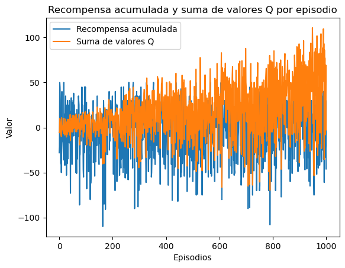

```
Q-values for epsilon = 0.4:
Q-values for product_A:
[[ 47.48593164  31.26597718   0.           0.           0.
    0.           0.           0.           0.           0.
    0.        ]
 [ 31.25100466   3.9373782   11.55431478   0.           0.
    0.           0.           0.           0.           0.
    0.        ]
 [  2.94084644  -0.31353145   1.45814104   2.35921742   0.
    0.           0.           0.           0.           0.
    0.        ]
 [ 38.65452468  14.10229394  11.93832407   0.           7.68807696
    0.           0.           0.           0.           0.
    0.        ]
 [ 46.95537671  -2.23307329  -3.38020176  -3.81789753  -1.16470819
    0.77643501  -1.64107503   0.           0.           0.
    0.        ]
 [ 43.94700028   0.07553032  12.69085788   0.11183965   8.29536235
    4.85497581   3.90858478   0.           0.           0.
    0.        ]
 [ 34.57793545  19.05405799  -0.11788348  11.6085879    2.48842728
    6.46105652   4.70442511  -2.08947545  -0.96958714   0.
    0.        ]
 [ 19.16639611  21.32884353   2.0988994   -4.20698902  -4.07497346
    0.90834332  -0.24261117  -0.86263408  -3.60672071   1.1273
    0.        ]
 [ 28.08701462  29.12792057  16.4623355   -1.1626984   13.91210018
    3.3546328   -0.31274241   0.23034936 -10.58127294  -4.96675721
   -3.6992556 ]
 [  2.65357498   9.81059502   7.89736046  -1.79154216   0.95538496
    1.4998348  -13.63591737 -16.9535003  -25.86874561 -14.74099499
  -22.95694438]
 [  7.1837573   -7.640805   -18.92030183  -6.75500386  -7.14135417
  -18.80028102 -18.64739265 -21.62057708 -27.9336736  -26.72966033
  -33.64103513]]
Q-values for product_B:
[[ 52.81343865  16.34736045   5.8505898    0.           0.
    0.           0.           0.           0.           0.
    0.        ]
 [ 38.89254438   4.79713881  10.01528192   8.35813938   0.
```

[output cut: 14 more lines]

```
 [ 50.36103785  17.71575564   9.85888442   4.49921747   1.50171186
   -1.11892224  -6.4108162    0.77826444  -2.56470384   0.
    0.        ]
 [ 35.80478528   5.29154096  10.69217064  -0.87883371  -1.33443941
   -4.03129904   6.99457175   0.38504195  -2.01409904   0.
    0.        ]
 [ 46.27232446  38.33531441   1.01417976  14.15396063  10.48418639
    0.88267209   2.13791151  -0.69877378  -5.23081726  -6.8288991
  -13.95938932]
 [ 12.28332357   4.50353843  -7.5680964    3.18142453  -6.3023418
  -10.24634655  -9.63833153 -15.19685686 -29.35267765 -12.5790531
  -25.98271175]
 [ -5.83141697  -7.88691653  -7.422997   -20.4599009  -14.42795327
  -26.79710577 -27.71045939 -38.47445752 -27.80427324 -45.36896105
  -63.18730939]]
```

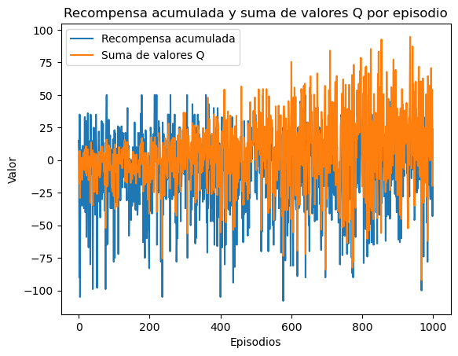

```
Q-values for epsilon = 0.5:
Q-values for product_A:
[[  2.30830912   7.33244971  12.04151074   0.           0.
    0.           0.           0.           0.           0.
    0.        ]
 [  7.48885182   4.74312364  12.23178998   3.30039394   0.
    0.           0.           0.           0.           0.
    0.        ]
 [ 27.75591875   6.67805219   1.99798771   6.54171371  -1.75062338
    0.           0.           0.           0.           0.
    0.        ]
 [ 49.03507308   8.75223381   1.42722771  10.56795626  -1.77655101
    4.71315658   0.           0.           0.           0.
    0.        ]
 [ 25.87543415  -0.6365739   11.31489115  -7.8805507  -10.56786019
   -3.4863044   -2.06806654   0.           0.           0.
    0.        ]
 [ 25.4003924    8.17243229  10.32994014   4.91284459   2.1812736
   -3.60499042   0.           1.53477484   0.           0.
    0.        ]
 [ 47.508717    36.82138305   3.15001362  11.64923815  -4.24487915
    9.18001355   7.2233756    3.01811005   2.27578453   0.
    0.        ]
 [ -5.24223901   6.76160581  -5.79480823   0.1753652   -6.78760576
   -1.92130839  -9.77977349  -5.23496037  -4.98795397  -0.40722055
    0.        ]
 [ 10.65769846  13.58857644  11.19274872   4.82233956  10.31985041
    4.47376239  -1.18378833  -7.90327195 -10.35787696 -22.0094135
  -21.44034312]
 [  6.60164278  24.3660763    6.4515944    0.18030233   1.28500772
   -9.91231594  -1.73225134 -20.79824242 -22.74321085 -33.89354003
  -26.37921345]
 [ -4.4025729   -7.65070595  -7.6005099   -8.08551228  -2.618648
   -9.1000748  -23.47617123 -26.59479141 -34.12746757 -39.90377702
  -38.05519443]]
Q-values for product_B:
[[ 13.46156337  16.16561224   0.           0.           0.
    0.           0.           0.           0.           0.
    0.        ]
 [ 24.4576899    6.17403216  19.1399876    0.           0.
```

[output cut: 14 more lines]

```
 [ 37.67959075   8.69858536  12.23737061  -1.48276527  -0.25829366
    5.16234928  -6.58944051   0.          -0.91312219   0.
    0.        ]
 [ 38.32538195   6.74429181  17.65050477   5.19221978   1.64925032
   -7.96628044  -3.2697814  -10.7186995   -3.97742496   0.
    0.        ]
 [ 45.22374495  20.32696659   7.31934005  22.35075567   7.82284026
    5.4935446   -2.23050249  -3.17661525 -22.7467145  -15.62794921
  -23.69941588]
 [  7.98341866  -1.48307499   2.16587029  -6.39909188  -3.76755647
  -18.82155283 -13.8680173  -25.24963293 -13.10897398 -39.16093399
  -51.06066006]
 [ -2.37262462 -10.77440732  -4.75073828  -5.54271    -24.23485691
  -11.4905725  -42.85715306 -47.56431556 -22.35397728 -48.27000449
  -47.51164035]]
```

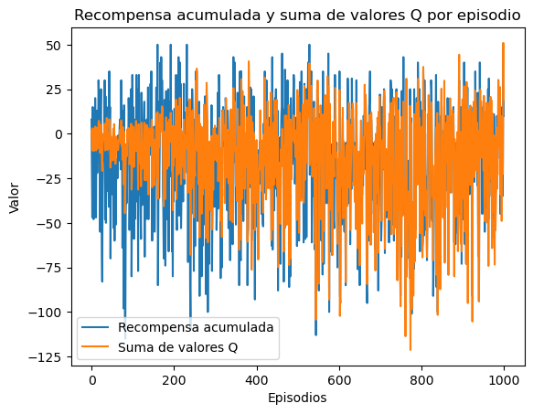

```
Q-values for epsilon = 0.6:
Q-values for product_A:
[[ -6.55654054  -1.4         -0.6462       0.           0.
    0.           0.           0.           0.           0.
    0.        ]
 [  7.83345783   6.37720372   9.20693789  -3.03485911   0.
    0.           0.           0.           0.           0.
    0.        ]
 [ -5.34310662  -7.30975996  -0.68504678   0.79302924  -6.58767382
    0.           0.           0.           0.           0.
    0.        ]
 [  4.49547466 -10.94668534  -1.94669664 -23.26441706   4.47
    1.27         0.           0.           0.           0.
    0.        ]
 [  6.0691672    9.81696047   1.83310438   0.51443415 -12.45302218
   -7.43644559  -4.54281139   0.           0.           0.
    0.        ]
 [ 13.9892189   -2.93351344   0.08398027   1.82889381   2.66593514
   -3.01708021  -7.82093375  -1.14049968   0.           0.
    0.        ]
 [ 15.41830367  -5.04252691   0.39983249 -10.28178382  -5.15315974
  -10.16322746  -2.7609462   -5.64532987  -3.02522678   0.
    0.        ]
 [  9.82137719  -2.78852633   2.41389619  -0.17069466 -22.03409117
  -14.67273518  -8.16513323   0.92860257  -3.15427349  -2.23556234
    0.        ]
 [ 21.32403603   7.70845281  -1.96817772   2.88692765  -8.7765549
    1.36807884 -11.70301716  -7.89863886  -1.84672957  -9.81562773
  -20.56351154]
 [ -3.88949746  -7.4665042  -10.26877265 -15.59405893 -14.3139982
  -18.89341071 -34.16149767 -45.70419458 -37.46386682 -33.87223508
  -39.31757871]
 [ -7.2074823   -9.16454558  -8.01887162 -16.23399557 -16.19628389
  -26.24405551 -19.94778772 -21.20497307 -38.35769797 -49.81078926
  -58.87342192]]
Q-values for product_B:
[[  3.72814911   0.53225974  -1.3216028    0.           0.
    0.           0.           0.           0.           0.
    0.        ]
 [  9.38832824  -8.52056846   4.05143252   7.6864367    0.
```

[output cut: 14 more lines]

```
 [  9.4105385    5.95429852  -4.40669379   4.00606327  -7.91348646
   -5.41292062 -18.83148564 -17.59029898  -4.56686558   0.
    0.        ]
 [ 16.63279239   8.18743616   5.09492798   2.42613129  -9.3355703
   -0.24948743 -15.04512204 -14.70571589 -12.84219917 -11.56462614
    0.        ]
 [  8.72021646   3.13980272   4.03700343   2.0570649    0.9689471
  -12.88769315 -14.74129736 -22.33598887 -16.04174839 -33.16042478
  -38.9008972 ]
 [  3.8112151  -10.44997799  -6.95706425 -11.4564954  -15.47009925
  -22.536826   -32.05028788 -31.91770289 -43.91577583 -46.9892099
  -53.51917581]
 [ -6.94525     -7.04300013 -14.23654193 -16.46980765 -22.24596802
  -21.96197338 -34.67840141 -42.6048427  -59.77519836 -60.53142185
  -77.23255724]]
```

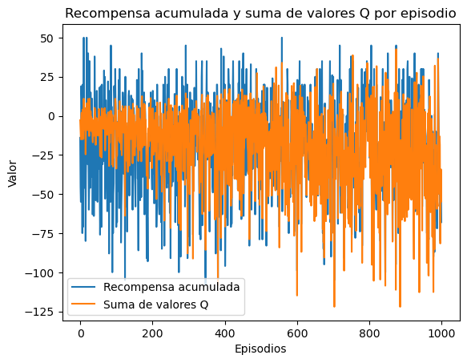

```
Q-values for epsilon = 0.7:
Q-values for product_A:
[[-2.10369482e+00  9.35532209e+00 -5.49869613e-02  0.00000000e+00
   0.00000000e+00  0.00000000e+00  0.00000000e+00  0.00000000e+00
   0.00000000e+00  0.00000000e+00  0.00000000e+00]
 [-1.16330500e+00 -1.21186336e+01 -4.32685040e+00 -3.87305825e+00
   0.00000000e+00  0.00000000e+00  0.00000000e+00  0.00000000e+00
   0.00000000e+00  0.00000000e+00  0.00000000e+00]
 [ 5.25074874e+00 -4.03294947e+00  7.71708262e+00  1.76896785e+00
   2.46948956e+00  0.00000000e+00  0.00000000e+00  0.00000000e+00
   0.00000000e+00  0.00000000e+00  0.00000000e+00]
 [-5.52453368e+00 -5.97997900e+00 -5.95433451e+00 -1.39365108e+01
  -1.22353794e+01 -2.80639513e+00  0.00000000e+00  0.00000000e+00
   0.00000000e+00  0.00000000e+00  0.00000000e+00]
 [ 5.48583617e+00  5.77522577e+00 -3.23696295e+00 -5.98965951e+00
  -8.44174758e+00 -1.73643549e+00 -9.78099713e+00  0.00000000e+00
   0.00000000e+00  0.00000000e+00  0.00000000e+00]
 [-1.04299756e+01 -7.74323540e+00 -8.04058055e+00 -3.10925368e+00
  -1.62715797e+01 -1.30000000e+00 -2.20000000e+00 -8.62000000e+00
   0.00000000e+00  0.00000000e+00  0.00000000e+00]
 [ 1.89724899e+00  3.41047043e+00 -5.59457734e+00  4.28796010e-01
  -1.37600493e+00 -9.40206520e+00 -8.02693273e-01 -8.08484200e+00
  -4.38657258e+00  0.00000000e+00  0.00000000e+00]
 [ 1.75938995e+01  2.37407465e+01  2.00928653e+00 -4.39657185e+00
  -1.36289160e+01  4.51006454e-01 -5.16289245e+00 -1.61348228e+01
  -1.09247706e+01 -3.10000000e+00  0.00000000e+00]
 [-3.01108521e+00 -9.52259717e+00 -3.21052138e+00 -9.54362466e+00
  -3.15366862e+00 -1.40111919e+01 -1.74675897e+01 -2.07629098e+01
  -2.80582254e+01 -2.02040381e+01 -3.17225261e+01]
 [-8.32652790e+00 -1.60969074e+01  1.51241732e+00 -1.69826256e+01
  -1.93710454e+01 -2.17810940e+01 -4.52474603e+01 -4.57823278e+01
  -4.06138227e+01 -4.95865001e+01 -3.80493871e+01]
 [-1.58196300e+01 -1.87880300e+01 -1.84979017e+01 -2.40196553e+01
  -2.32151968e+01 -3.94752717e+01 -3.55323712e+01 -4.86800725e+01
  -4.81049521e+01 -4.96529014e+01 -6.41389253e+01]]
Q-values for product_B:
[[  2.10463453  -2.3968634    0.1          0.           0.
    0.           0.           0.           0.           0.
    0.        ]
 [ 23.79373572   0.55937866   5.02500994   3.1181014    0.
```

[output cut: 14 more lines]

```
 [  2.34057948   5.54350507  -8.9118503   -1.84036947 -15.30924617
   -4.39096332 -18.42262395  -9.9314523   -1.23392975   0.
    0.        ]
 [  0.90388474  -0.10954148  -5.11085024  -8.09977577  -2.45606086
   -9.59306451 -14.29409776 -19.72104921  -8.44244401  -7.79484659
    0.        ]
 [  6.43861763   4.84131891  -0.68840978  -1.9070669   -6.36224435
  -13.45479903 -13.05446244 -28.09993414 -32.05577381 -31.31177268
  -32.28922316]
 [  1.21392871  -4.57912489 -12.78703491 -14.39736021 -20.98150262
  -22.28246629 -32.30244854 -35.96824627 -49.25618709 -50.44375527
  -65.46323743]
 [-14.79599871 -12.95630425 -14.47763437 -25.55616032 -30.48116499
  -27.98548368 -34.28643248 -60.19576207 -58.72222921 -63.84111899
  -75.1978743 ]]
```

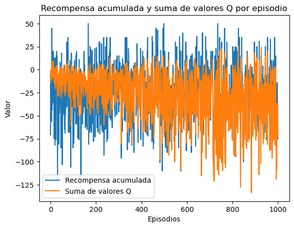

```
Q-values for epsilon = 0.8:
Q-values for product_A:
[[ -9.73236848 -13.95185722  -2.51         0.           0.
    0.           0.           0.           0.           0.
    0.        ]
 [-12.02620458  -1.10588484  -9.9250564   -0.29420188   0.
    0.           0.           0.           0.           0.
    0.        ]
 [  1.77124401  -7.09753457  -5.41068549 -14.08509455  -3.42054692
    0.           0.           0.           0.           0.
    0.        ]
 [  0.42869769  -4.44261608  -7.04854013 -17.64690978  -4.1746617
   -9.89482112   0.           0.           0.           0.
    0.        ]
 [ -6.30659216  -1.90248664  -6.88112791 -21.88612484 -20.31004226
  -17.95757252  -0.13012794   0.           0.           0.
    0.        ]
 [ -5.78502      3.54277035 -14.89337265 -13.0119     -21.81691134
  -18.79207574  -5.61044478   0.           0.           0.
    0.        ]
 [-11.13703512   0.6607662  -10.89717762  -7.56116169 -15.93899387
  -13.15348434 -21.196842   -18.53631002 -20.0333358    0.
    0.        ]
 [  4.9757199   -0.2106711   -1.24104837 -12.05958194 -12.29783108
   -2.32552286  -7.36715477 -12.80738164 -20.59260726  -7.51493455
    0.        ]
 [-18.48036588   2.11544019  -6.48139007  -0.94620819  -6.13197438
  -16.39925515 -29.82500038 -23.59518688 -33.77823063 -32.77491695
  -37.77314617]
 [  2.6891376  -10.4140695   -8.98297604  -1.62404468 -28.03454314
  -29.77575751 -27.54615377 -42.91916717 -39.08012222 -34.07334993
  -43.52916052]
 [-14.84175146 -15.32469253 -17.68596262 -18.81899179 -29.66046399
  -41.97788893 -38.88459966 -58.09693522 -47.62333174 -70.3757975
  -63.53285387]]
Q-values for product_B:
[[-2.51606651e+00 -2.33731261e+00 -1.57966931e+00  0.00000000e+00
   0.00000000e+00  0.00000000e+00  0.00000000e+00  0.00000000e+00
   0.00000000e+00  0.00000000e+00  0.00000000e+00]
 [ 5.30496947e+00 -3.81186090e-03 -2.65059577e+00 -1.98710570e+00
```

[output cut: 14 more lines]

```
 [-2.88118586e+00  7.07289491e-01  4.79693446e+00 -1.09767331e+01
  -1.26835626e+01 -2.06889830e+01 -1.19055238e+01 -1.41508272e+01
  -1.45812306e+01  0.00000000e+00  0.00000000e+00]
 [ 2.09481840e+01 -3.16095436e+00  1.08887627e+00 -4.26329780e+00
  -1.57011972e+01 -1.48367867e+01 -1.04973587e+01 -2.09703843e+01
  -1.02855569e+01 -8.13168817e+00  0.00000000e+00]
 [ 2.25127485e+01  3.20380814e+00  1.42008842e+00 -7.12445536e-02
   4.23211515e-01 -7.89175381e+00 -2.21365942e+01 -2.28923981e+01
  -3.23119007e+01 -3.15491710e+01 -3.67149546e+01]
 [ 3.50584426e+00 -7.41645828e+00 -8.46415541e+00 -8.39058372e+00
  -2.01520645e+01 -2.31356029e+01 -3.70428714e+01 -4.79879102e+01
  -4.39415365e+01 -6.08025424e+01 -5.97189971e+01]
 [-1.07789984e+01 -1.24314204e+01 -2.11129777e+01 -3.16928348e+01
  -3.99524266e+01 -3.89111043e+01 -4.28833288e+01 -4.79073137e+01
  -6.66528358e+01 -6.98659966e+01 -7.66474333e+01]]
```

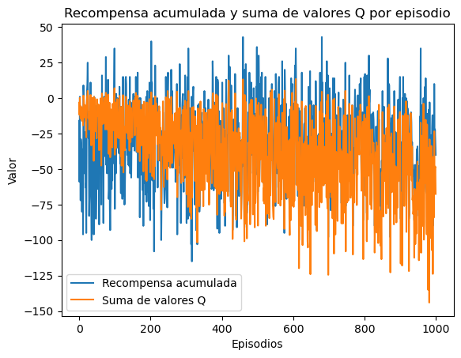

```
Q-values for epsilon = 0.9:
Q-values for product_A:
[[ -2.19236744 -13.96315009  -4.8105       0.           0.
    0.           0.           0.           0.           0.
    0.        ]
 [ -6.364035    -9.49963485  -3.7857      -1.214385     0.
    0.           0.           0.           0.           0.
    0.        ]
 [-13.69233476  -5.437239   -14.87090513  -6.89430435   1.485
    0.           0.           0.           0.           0.
    0.        ]
 [ -4.02280022  -3.57159177  -5.9153941  -42.87222346 -10.33390569
   -6.6002961    0.           0.           0.           0.
    0.        ]
 [-11.06089373 -12.53564132  -2.6796     -14.98798473 -14.43715016
  -11.85264116 -10.8          0.           0.           0.
    0.        ]
 [ -3.8053981  -13.42319864 -14.09276282 -25.23643961 -12.35281134
   -8.35912247 -10.046065   -13.284        0.           0.
    0.        ]
 [ -6.57286619 -21.32603486 -12.192402   -21.90403347 -18.01237758
  -16.06676088 -28.45062092 -21.98847605  -5.34406407   0.
    0.        ]
 [ -4.81568798 -18.85772418  -8.77770023  -5.68562792 -12.26854576
  -13.0272747  -15.30695159 -36.49243277 -13.08363487 -12.97169891
    0.        ]
 [ -5.81329338  -0.70701842 -19.50667905 -14.17334199 -21.16852598
  -23.71252254 -23.45773999 -36.04063381 -36.99344489 -34.55651345
  -39.33779644]
 [ -1.3256377  -13.02144019 -13.54781548 -10.85468068 -18.96772335
  -22.40998403 -42.91619884 -46.59244843 -43.90855946 -42.6018207
  -48.47048494]
 [ -4.81391785 -18.7229156  -25.92276225 -30.15102939 -26.5435973
  -32.19479001 -46.92255785 -54.16901239 -57.05076858 -64.48354604
  -69.81288063]]
Q-values for product_B:
[[-5.14032415e-02 -2.70000000e+00 -8.47003814e+00  0.00000000e+00
   0.00000000e+00  0.00000000e+00  0.00000000e+00  0.00000000e+00
   0.00000000e+00  0.00000000e+00  0.00000000e+00]
 [ 1.86670985e+00 -2.37656848e+00 -1.24572248e-01 -1.96507662e-01
```

[output cut: 14 more lines]

```
 [-5.36361720e+00 -9.11401593e-01 -5.67808779e+00 -5.19517190e+00
  -7.61583993e+00 -2.12445684e+01 -2.48794025e+01 -8.54360000e+00
   0.00000000e+00  0.00000000e+00  0.00000000e+00]
 [-1.75935496e+00 -1.01552537e+00 -3.67115047e+00 -9.21902223e+00
  -1.11654595e+01 -1.59640018e+01 -2.43218537e+01 -3.48032423e+01
  -1.48251456e+01 -1.31948539e+01  0.00000000e+00]
 [-7.42473945e-02 -2.71619377e+00 -4.09876122e+00 -3.07729754e+00
  -1.03445531e+01 -3.13518475e+01 -2.57976571e+01 -3.03454628e+01
  -4.71235209e+01 -4.45633974e+01 -5.26523970e+01]
 [-9.54849916e+00 -8.68843426e+00 -1.31329839e+01 -2.28915139e+01
  -2.45336890e+01 -4.35133071e+01 -4.14223980e+01 -4.28051539e+01
  -6.26035797e+01 -5.71512444e+01 -6.04466750e+01]
 [-6.74902000e+00 -5.27291770e+00 -2.62033024e+01 -3.46555526e+01
  -3.94987506e+01 -3.42750512e+01 -5.43622052e+01 -5.07906425e+01
  -6.62203647e+01 -7.95748447e+01 -7.89816451e+01]]
```

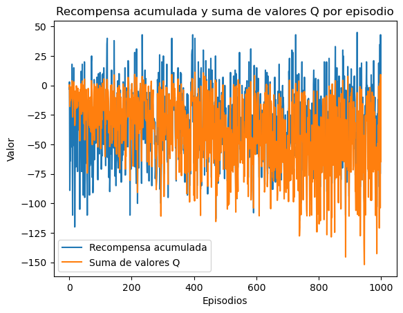

```
Q-values for epsilon = 0.99:
Q-values for product_A:
[[-16.51936121   2.39410693   2.174        0.           0.
    0.           0.           0.           0.           0.
    0.        ]
 [-10.84553892  -6.3751305  -10.6111452   -0.66055      0.
    0.           0.           0.           0.           0.
    0.        ]
 [ -0.96866025  -1.83142526  -8.32108943  -2.3167367    1.237721
    0.           0.           0.           0.           0.
    0.        ]
 [  2.90779754   1.29099869   7.93894317 -13.04817464 -12.67053287
    0.           0.           0.           0.           0.
    0.        ]
 [ -2.54491687 -10.64401111   5.08372424 -20.61403673 -15.61689482
   -6.40027637 -22.53725266   0.           0.           0.
    0.        ]
 [-10.88201665  -2.29258086  -8.68505509  -7.15173437 -19.21254143
  -19.12513335 -11.20182423  -8.50136365   0.           0.
    0.        ]
 [  1.78961612   1.1626305   -9.91669499 -16.48332425 -16.88587515
  -11.22747289 -14.11268271 -12.37830796   0.           0.
    0.        ]
 [ -5.24793404 -17.66689271 -13.95899332 -12.60320962  -9.01206305
   -5.62263728 -10.89174937 -19.83616033 -12.96699437  -4.6
    0.        ]
 [-17.71521974  -8.01496188 -17.36898798 -16.33450007 -24.44437214
  -37.37747646 -37.78382274 -45.51206331 -52.70447718 -45.46124116
  -49.96414591]
 [-13.97096286 -14.11086246  -9.96049116 -13.53832412 -45.90452237
  -38.16412395 -30.43700688 -48.16131295 -58.45219934 -57.21861337
  -59.29521638]
 [ -4.74414    -10.10192951 -14.40969331 -39.84817345 -21.01324674
  -34.85663221 -49.88066996 -44.1223768  -66.86320275 -58.7598387
  -63.74412507]]
Q-values for product_B:
[[ -5.36317067   3.82831396   0.81443001   0.           0.
    0.           0.           0.           0.           0.
    0.        ]
 [  0.64934152  -6.00909237  -3.12729772  -2.27239882   0.
```

[output cut: 14 more lines]

```
 [  7.21529631   6.33219869  -3.64135     -1.54479425 -19.76077161
  -11.90282168  -9.44862668 -17.58615012 -11.005        0.
    0.        ]
 [ -4.18486477   1.45391643  -7.58925325 -14.02450209 -13.35892701
  -13.56580158 -12.76804415 -33.56940323 -11.97508823 -16.23836199
    0.        ]
 [  7.22837671  -6.66800059  -5.93837077  -5.20085371 -12.76063751
  -20.59725274 -22.98751047 -30.38157267 -41.58773946 -44.86777215
  -50.68573563]
 [  0.52082365 -12.90694236 -18.58300102 -22.67571996 -18.97504933
  -35.32852687 -38.83324573 -51.95892611 -43.2161027  -58.81676696
  -64.8208285 ]
 [ -8.96        -5.104757   -28.79706397 -24.42338024 -35.10279134
  -32.09206604 -52.70839344 -52.72868264 -71.05830414 -75.78975161
  -87.36697005]]
```

```python
epsilons = [0.1, 0.2, 0.3, 0.4, 0.5, 0.6, 0.7, 0.8, 0.9, 0.99]
env = InventoryEnvironment()

for eps in epsilons:
    Q_values = off_policy_q_learning(env, num_episodes=1000, epsilon=eps)
    print(f"Q-values for epsilon = {eps}:")

    for product in env.products:
        print(f"Q-values for {product}:")
        print(Q_values[product])
```